# Assignment5

Jordi Florit Ensenyat, Josep Gabriel Fornes Reynes and Pau Girón Rodríguez

2025-01-11

## **1. Introduction**

In this assignment, we will analyze association rules using the BreadBasket dataset, which contains information on transactions made in a bakery. This analysis is a key aspect of data mining, particularly in identifying frequent patterns within large volumes of transactional data.

The main objective of this task is to apply data mining techniques to discover frequent itemsets and generate association rules that reveal meaningful relationships between purchased products. Additionally, we will explore methods to identify redundant rules and evaluate techniques for effectively visualizing these rules.

## **2. Importing data**

We have to sets up the environment for association rule mining. So we use this function that read transactional data from the BreadBasket.csv file and convert it into a format suitable for processing with `arules` functions.

```r
library(arules)
transactionBD <- read.transactions("BreadBasket.csv", format = "single", sep = ",", cols = c("Transaction", "Item"), header = TRUE)
```

## **3. Data Analisis**

```r
summary(transactionBD)
```

```
## transactions as itemMatrix in sparse format with
##  6576 rows (elements/itemsets/transactions) and
##  102 columns (items) and a density of 0.01988962
##
## most frequent items:
##  Coffee   Bread     Tea    Cake  Pastry (Other)
##    3188    2146     941     694     576    5796
##
## element (itemset/transaction) length distribution:
## sizes
##    1    2    3    4    5    6    7    8    9   10
## 2652 2155 1029  502  174   47   10    2    4    1
##
##    Min. 1st Qu.  Median    Mean 3rd Qu.    Max.
##   1.000   1.000   2.000   2.029   3.000  10.000
##
## includes extended item information - examples:
##                     labels
## 1               Adjustment
## 2 Afternoon with the baker
## 3                Alfajores
##
## includes extended transaction information - examples:
##   transactionID
## 1             1
## 2            10
## 3          1000
```

To view the transactions, use the “inspect()” function instead, because the “head()” function does not display the transaction items.

```r
inspect(transactionBD[1:4,])  # too many transactions, only look at the first 4
```

```
##     items                           transactionID
## [1] {Bread}                         1
## [2] {Medialuna, Scandinavian}       10
## [3] {Chimichurri Oil, Scandinavian} 1000
## [4] {Bread, Truffles}               1001
```

Since association mining deals with transactions, the data has to be converted to one of class transactions, made available in R through the “arules” package. This is a necessary step because the “apriori()” function only accepts transactions data of class transactions.

```r
class(transactionBD)
```

```
## [1] "transactions"
## attr(,"package")
## [1] "arules"
```

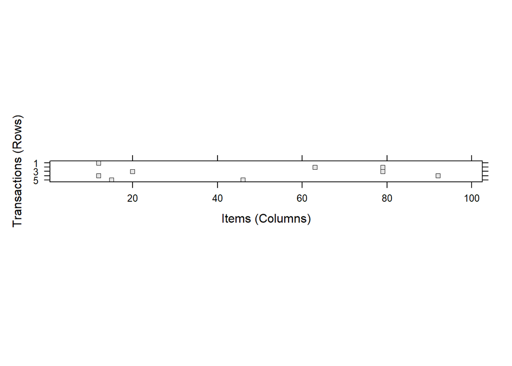

```r
image(transactionBD[1:5]) # a visualization of the sparse matrix for the first five transactions
```

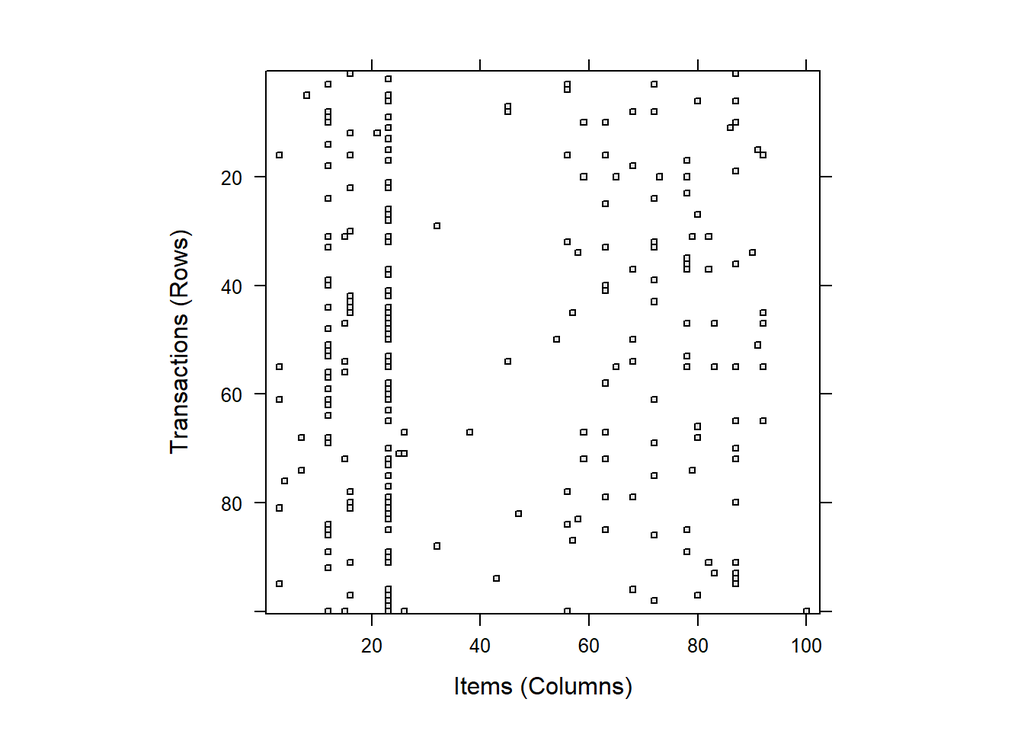

```r
image(sample(transactionBD, 100))
```

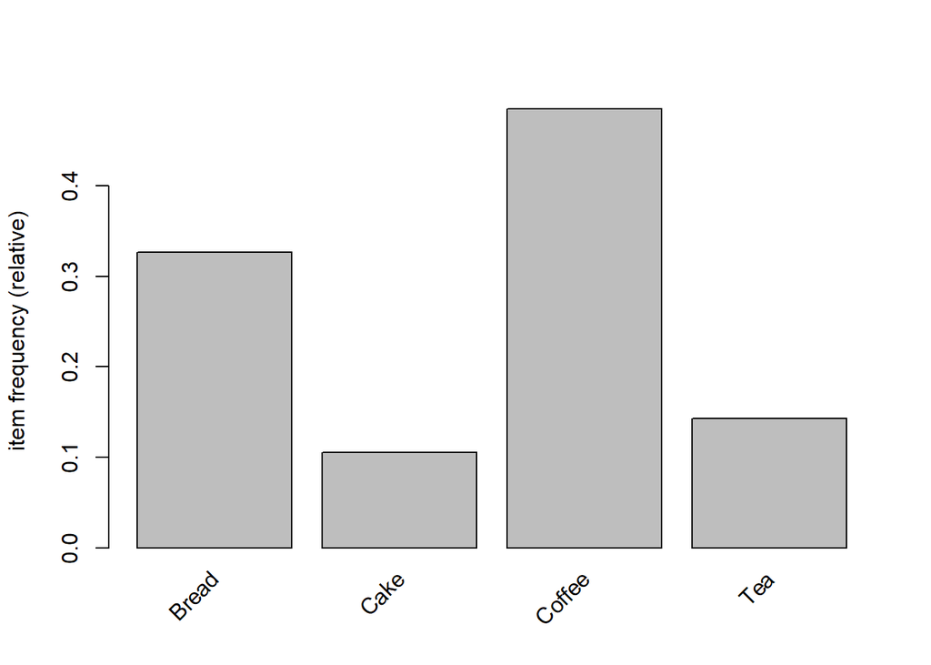

```r
itemFrequencyPlot(transactionBD, support = 0.1) ## minimum support 0.1
```

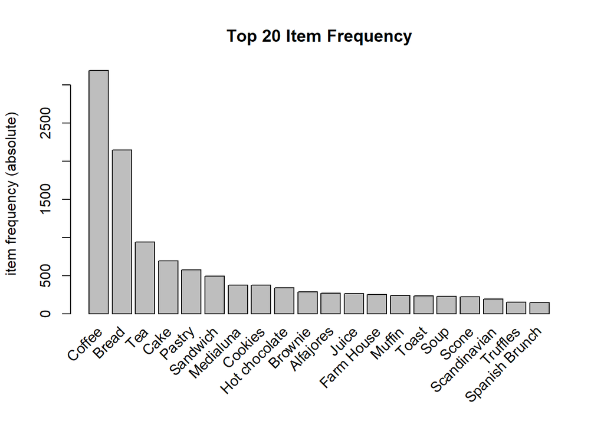

```r
itemFrequencyPlot(transactionBD, topN = 20, type="absolute", main="Top 20 Item Frequency")   ## plot of top 20 most frequent items
```

A rule is a notation that represents which item/s is frequently bought with what item/s. It has an LHS and an RHS part and can be represented as: $A \rightarrow B$. This means, the item/s in $B$ were frequently purchased along with items of $A$.

The “apriori()” function generates the most relevant set of rules from a given transaction data. It also shows the support, confidence and lift of those rules. These three measure can be used to decide the relative strength of the rules. So what do these terms mean?

- “support” is how many transactions support the condition.
  $$s(A \rightarrow B) = \frac{\sigma(A,B)}{|T|} =
  P(A \cup B)$$
- “confidence” is how confident the condition is.
  $$c(A \rightarrow B) = \frac{s(A \rightarrow
  B)}{s(A)} = \frac{P(A \cup B)}{P(A)}$$
- “lift” is how often the condition actually happened compared to the estimated chance for that to happen (expected value).
  $$lift(A \rightarrow B) = \frac{c(A \rightarrow
  B)}{s(B)} = \frac{P(A \cup B)}{P(A)\cdot P(B)}$$
  Lift is the factor by which, the co-occurrence of A and B exceeds the expected probability of A and B co-occurring, had they been independent. So, higher the lift, higher the chance of A and B occurring together.

```r
frequentItems <- eclat(transactionBD, parameter = list(support = 0.05)) # calculates support for frequent items
```

```
## Eclat
##
## parameter specification:
##  tidLists support minlen maxlen            target  ext
##     FALSE    0.05      1     10 frequent itemsets TRUE
##
## algorithmic control:
##  sparse sort verbose
##       7   -2    TRUE
##
## Absolute minimum support count: 328
##
## create itemset ...
## set transactions ...[102 item(s), 6576 transaction(s)] done [0.00s].
## sorting and recoding items ... [9 item(s)] done [0.00s].
## creating bit matrix ... [9 row(s), 6576 column(s)] done [0.00s].
## writing  ... [12 set(s)] done [0.00s].
## Creating S4 object  ... done [0.00s].
```

```r
inspect(frequentItems)
```

```
##      items           support    count
## [1]  {Cake, Coffee}  0.05687348  374
## [2]  {Coffee, Tea}   0.05200730  342
## [3]  {Bread, Coffee} 0.09032847  594
## [4]  {Coffee}        0.48479319 3188
## [5]  {Bread}         0.32633820 2146
## [6]  {Tea}           0.14309611  941
## [7]  {Cake}          0.10553528  694
## [8]  {Pastry}        0.08759124  576
## [9]  {Sandwich}      0.07496959  493
## [10] {Cookies}       0.05687348  374
## [11] {Medialuna}     0.05763382  379
## [12] {Hot chocolate} 0.05200730  342
```

```r
frequentItems2 <- eclat(transactionBD, parameter = list(support = 0.01)) # calculates support for frequent items
```

```
## Eclat
##
## parameter specification:
##  tidLists support minlen maxlen            target  ext
##     FALSE    0.01      1     10 frequent itemsets TRUE
##
## algorithmic control:
##  sparse sort verbose
##       7   -2    TRUE
##
## Absolute minimum support count: 65
##
## create itemset ...
## set transactions ...[102 item(s), 6576 transaction(s)] done [0.00s].
## sorting and recoding items ... [30 item(s)] done [0.00s].
## creating sparse bit matrix ... [30 row(s), 6576 column(s)] done [0.00s].
## writing  ... [61 set(s)] done [0.00s].
## Creating S4 object  ... done [0.00s].
```

```r
inspect(frequentItems2)
```

```
##      items                    support    count
## [1]  {Coffee, Tiffin}         0.01064477   70
## [2]  {Coffee, Spanish Brunch} 0.01414234   93
## [3]  {Coffee, Scone}          0.01855231  122
## [4]  {Coffee, Toast}          0.02585158  170
## [5]  {Coffee, Muffin}         0.01809611  119
## [6]  {Coffee, Soup}           0.01718370  113
## [7]  {Alfajores, Coffee}      0.02250608  148
## [8]  {Alfajores, Bread}       0.01125304   74
## [9]  {Brownie, Coffee}        0.02098540  138
## [10] {Bread, Brownie}         0.01186131   78
## [11] {Coffee, Juice}          0.02144161  141
## [12] {Coffee, Hot chocolate}  0.02737226  180
## [13] {Bread, Hot chocolate}   0.01201338   79
## [14] {Cake, Hot chocolate}    0.01034063   68
```

[output cut: 47 more lines]

```r
summary(frequentItems2)
```

```
## set of 61 itemsets
##
## most frequent items:
##        Coffee         Bread          Cake           Tea Hot chocolate
##            20            12             6             6             4
##       (Other)
##            46
##
## element (itemset/transaction) length distribution:sizes
##  1  2  3
## 30 29  2
##
##    Min. 1st Qu.  Median    Mean 3rd Qu.    Max.
##   1.000   1.000   2.000   1.541   2.000   3.000
##
## summary of quality measures:
##     support            count
##  Min.   :0.01004   Min.   :  66.0
##  1st Qu.:0.01521   1st Qu.: 100.0
##  Median :0.02342   Median : 154.0
##  Mean   :0.04451   Mean   : 292.7
##  3rd Qu.:0.04075   3rd Qu.: 268.0
##  Max.   :0.48479   Max.   :3188.0
##
## includes transaction ID lists: FALSE
##
## mining info:
##           data ntransactions support
##  transactionBD          6576    0.01
##                                                           call
##  eclat(data = transactionBD, parameter = list(support = 0.01))
```

## 4. Associtation Rules: Apriori

The following code performs an association rule analysis using the Apriori algorithm on a transactional dataset (`transactionBD`). The analysis includes various settings for the algorithm parameters in order to identify frequent patterns in the data.

### Step 1: Initial Rule Generation

In this step, an initial set of association rules is generated using the default parameters of the apriori algorithm. The rules object contains the generated rules. When executed, we can see a basic summary of the rules created. So we can see that the default parameters are too restrictive for this dataset and need to be adjusted.

```r
rules <- apriori(transactionBD)
```

```
## Apriori
##
## Parameter specification:
##  confidence minval smax arem  aval originalSupport maxtime support minlen
##         0.8    0.1    1 none FALSE            TRUE       5     0.1      1
##  maxlen target  ext
##      10  rules TRUE
##
## Algorithmic control:
##  filter tree heap memopt load sort verbose
##     0.1 TRUE TRUE  FALSE TRUE    2    TRUE
##
## Absolute minimum support count: 657
##
## set item appearances ...[0 item(s)] done [0.00s].
## set transactions ...[102 item(s), 6576 transaction(s)] done [0.00s].
## sorting and recoding items ... [4 item(s)] done [0.00s].
## creating transaction tree ... done [0.00s].
## checking subsets of size 1 2 done [0.00s].
## writing ... [0 rule(s)] done [0.00s].
## creating S4 object  ... done [0.00s].
```

```r
summary(rules)
```

```
## set of 0 rules
```

### Step 2: Testing the algorithm

Here, parameters are adjusted to generate more meaningful rules:

- supp = 0.01: A minimum support of 1% is set, indicating that rules must be present in at least 1% of transactions.
- conf = 0.5: A minimum confidence of 50% is set, implying that rules must have at least a 50% probability of being fulfilled.
- minlen = 2: A minimum length of 2 is set for rules, ensuring that they involve at least two elements.

```r
rules <- apriori(transactionBD, parameter = list(supp = 0.01, conf = 0.5, minlen=2))
```

```
## Apriori
##
## Parameter specification:
##  confidence minval smax arem  aval originalSupport maxtime support minlen
##         0.5    0.1    1 none FALSE            TRUE       5    0.01      2
##  maxlen target  ext
##      10  rules TRUE
##
## Algorithmic control:
##  filter tree heap memopt load sort verbose
##     0.1 TRUE TRUE  FALSE TRUE    2    TRUE
##
## Absolute minimum support count: 65
##
## set item appearances ...[0 item(s)] done [0.00s].
## set transactions ...[102 item(s), 6576 transaction(s)] done [0.00s].
## sorting and recoding items ... [30 item(s)] done [0.00s].
## creating transaction tree ... done [0.00s].
## checking subsets of size 1 2 3 done [0.00s].
## writing ... [12 rule(s)] done [0.00s].
## creating S4 object  ... done [0.00s].
```

```r
summary(rules)
```

```
## set of 12 rules
##
## rule length distribution (lhs + rhs):sizes
##  2
## 12
##
##    Min. 1st Qu.  Median    Mean 3rd Qu.    Max.
##       2       2       2       2       2       2
##
## summary of quality measures:
##     support          confidence        coverage            lift
##  Min.   :0.01064   Min.   :0.5263   Min.   :0.01946   Min.   :1.086
##  1st Qu.:0.02072   1st Qu.:0.5367   1st Qu.:0.03513   1st Qu.:1.107
##  Median :0.02661   Median :0.5496   Median :0.04638   Median :1.134
##  Mean   :0.02934   Mean   :0.5690   Mean   :0.05227   Mean   :1.174
##  3rd Qu.:0.03551   3rd Qu.:0.5698   3rd Qu.:0.06197   3rd Qu.:1.175
##  Max.   :0.05687   Max.   :0.7296   Max.   :0.10554   Max.   :1.505
##      count
##  Min.   : 70.0
##  1st Qu.:136.2
##  Median :175.0
##  Mean   :192.9
##  3rd Qu.:233.5
##  Max.   :374.0
##
## mining info:
##           data ntransactions support confidence
##  transactionBD          6576    0.01        0.5
##                                                                                  call
##  apriori(data = transactionBD, parameter = list(supp = 0.01, conf = 0.5, minlen = 2))
```

12 rules are generated that meet the tuned parameters.

The summary shows:

- The distribution of rule lengths: all rules have a length of 2.
- The quality measures (support, confidence, lift) for each rule.

```r
inspect(rules)
```

```
##      lhs                 rhs      support    confidence coverage   lift
## [1]  {Tiffin}         => {Coffee} 0.01064477 0.5468750  0.01946472 1.128058
## [2]  {Spanish Brunch} => {Coffee} 0.01414234 0.6326531  0.02235401 1.304996
## [3]  {Scone}          => {Coffee} 0.01855231 0.5422222  0.03421533 1.118461
## [4]  {Toast}          => {Coffee} 0.02585158 0.7296137  0.03543187 1.505000
## [5]  {Alfajores}      => {Coffee} 0.02250608 0.5522388  0.04075426 1.139122
## [6]  {Juice}          => {Coffee} 0.02144161 0.5300752  0.04045012 1.093405
## [7]  {Hot chocolate}  => {Coffee} 0.02737226 0.5263158  0.05200730 1.085650
## [8]  {Medialuna}      => {Coffee} 0.03315085 0.5751979  0.05763382 1.186481
## [9]  {Cookies}        => {Coffee} 0.02995742 0.5267380  0.05687348 1.086521
## [10] {Sandwich}       => {Coffee} 0.04257908 0.5679513  0.07496959 1.171533
## [11] {Pastry}         => {Coffee} 0.04896594 0.5590278  0.08759124 1.153126
## [12] {Cake}           => {Coffee} 0.05687348 0.5389049  0.10553528 1.111618
##      count
## [1]   70
## [2]   93
## [3]  122
## [4]  170
## [5]  148
## [6]  141
## [7]  180
## [8]  218
## [9]  197
## [10] 280
## [11] 322
## [12] 374
```

This step allows to inspect the generated rules in detail, displaying information such as the support, confidence, and lift of each rule.

### Step 3: Refining the parameters

To explore how different values of support, confidence, and minimum length affect the generated rules, a function is defined that iterates over various combinations of these parameters:

**Input parameters**:

- df: The transactional dataset.
- supp_values: A list of support values.
- conf_values: A list of confidence values.
- minlen_values: A list of minimum length values.

**Outputs**:

A data.frame is returned that contains, for each combination of parameters:

- The number of redundant rules (Redundant_Rules).
- The number of non-redundant rules (Non_Redundant_Rules).

The lists of support, confidence, and minimum length values to be used in the loop are defined. The `run_apriori_with_loop` function is run with these combinations, allowing to evaluate how the parameters affect the performance and results of the algorithm.

Parameters evaluated:

- Support values: 0.005, 0.01, 0.02
- Confidence values: 0.4, 0.5, 0.6, 0.7
- Minlen values: 1, 2, 3

```r
run_apriori_with_loop <- function(df, supp_values, conf_values, minlen_values) {
  result_df <- data.frame()

  for (supp_val in supp_values) {
    for (conf_val in conf_values) {
      for (minlen_val in minlen_values) {
        rules <- apriori(
          df,
          parameter = list(
            supp = supp_val,
            conf = conf_val,
            minlen = minlen_val
          )
        )
        red_rules <- rules[is.redundant(rules)]
        not_red_rules <- rules[!is.redundant(rules)]
        rules_conf <- sort(not_red_rules, by = "lift", decreasing = TRUE)
        result_df <- rbind(
          result_df,
          data.frame(
            Support = supp_val,
            Confidence = conf_val,
            MinLength = minlen_val,
            Redundant_Rules = length(red_rules),
            Non_Redundant_Rules = length(not_red_rules)
          )
        )
      }
    }
  }

  return(result_df)
}


supp_values <- c(0.005, 0.01, 0.02)
conf_values <- c(0.4, 0.5, 0.6, 0.7)
minlen_values <- c(1, 2, 3)

run_apriori_with_loop(
  transactionBD,
  supp_values,
  conf_values,
  minlen_values
)
```

[output not shown]

[output cut: 701 more lines]

[output not shown]

```
##    Support Confidence MinLength Redundant_Rules Non_Redundant_Rules
## 1    0.005        0.4         1               9                  20
## 2    0.005        0.4         2               6                  22
## 3    0.005        0.4         3               0                   8
## 4    0.005        0.5         1               0                  17
## 5    0.005        0.5         2               0                  17
## 6    0.005        0.5         3               0                   2
## 7    0.005        0.6         1               0                   5
## 8    0.005        0.6         2               0                   5
## 9    0.005        0.6         3               0                   2
## 10   0.005        0.7         1               0                   2
## 11   0.005        0.7         2               0                   2
## 12   0.005        0.7         3               0                   1
## 13   0.010        0.4         1               2                  15
## 14   0.010        0.4         2               1                  15
```

[output cut: 22 more lines]

### Step 4. Redundant Rules Treatment

To show how to remove the redundant rules, another configuration is going to be used.

Once the parameters are selected (support = 0.005, confidence = 0.4, minlen = 2), 28 rules are generated. These rules are divided into:

```r
rules <- apriori(
          transactionBD,
          parameter = list(
            supp = 0.005,
            conf = 0.4,
            minlen = 2
          )
        )
```

```
## Apriori
##
## Parameter specification:
##  confidence minval smax arem  aval originalSupport maxtime support minlen
##         0.4    0.1    1 none FALSE            TRUE       5   0.005      2
##  maxlen target  ext
##      10  rules TRUE
##
## Algorithmic control:
##  filter tree heap memopt load sort verbose
##     0.1 TRUE TRUE  FALSE TRUE    2    TRUE
##
## Absolute minimum support count: 32
##
## set item appearances ...[0 item(s)] done [0.00s].
## set transactions ...[102 item(s), 6576 transaction(s)] done [0.00s].
## sorting and recoding items ... [37 item(s)] done [0.00s].
## creating transaction tree ... done [0.00s].
## checking subsets of size 1 2 3 4 done [0.00s].
## writing ... [28 rule(s)] done [0.00s].
## creating S4 object  ... done [0.00s].
```

```r
red_rules <- rules[is.redundant(rules)]
inspect(red_rules)
```

```
##     lhs                       rhs      support     confidence coverage
## [1] {Bread, Hot chocolate} => {Coffee} 0.005474453 0.4556962  0.01201338
## [2] {Bread, Medialuna}     => {Coffee} 0.007147202 0.4351852  0.01642336
## [3] {Sandwich, Tea}        => {Coffee} 0.006082725 0.4301075  0.01414234
## [4] {Bread, Sandwich}      => {Coffee} 0.007755474 0.4553571  0.01703163
## [5] {Cake, Tea}            => {Coffee} 0.011253041 0.4277457  0.02630779
## [6] {Bread, Cake}          => {Coffee} 0.009732360 0.4155844  0.02341849
##     lift      count
## [1] 0.9399806 36
## [2] 0.8976718 47
## [3] 0.8871980 40
## [4] 0.9392812 51
## [5] 0.8823261 74
## [6] 0.8572406 64
```

Redundant rules (6 rules): Rules that can be derived from other rules with greater generality.

Also for see non-redundant:

```r
not_red_rules <- rules[!is.redundant(rules)]
inspect(not_red_rules)
```

```
##      lhs                      rhs      support     confidence coverage
## [1]  {Hearty & Seasonal}   => {Coffee} 0.005474453 0.5454545  0.010036496
## [2]  {Salad}               => {Coffee} 0.007907543 0.6117647  0.012925791
## [3]  {Jammie Dodgers}      => {Coffee} 0.007299270 0.5161290  0.014142336
## [4]  {Chicken Stew}        => {Coffee} 0.006082725 0.4123711  0.014750608
## [5]  {Mineral water}       => {Coffee} 0.006995134 0.4220183  0.016575426
## [6]  {Tiffin}              => {Coffee} 0.010644769 0.5468750  0.019464720
## [7]  {Spanish Brunch}      => {Coffee} 0.014142336 0.6326531  0.022354015
## [8]  {Scone}               => {Coffee} 0.018552311 0.5422222  0.034215328
## [9]  {Toast}               => {Coffee} 0.025851582 0.7296137  0.035431873
## [10] {Muffin}              => {Coffee} 0.018096107 0.4958333  0.036496350
## [11] {Soup}                => {Coffee} 0.017183698 0.4870690  0.035279805
## [12] {Alfajores}           => {Coffee} 0.022506083 0.5522388  0.040754258
## [13] {Brownie}             => {Coffee} 0.020985401 0.4758621  0.044099757
## [14] {Juice}               => {Coffee} 0.021441606 0.5300752  0.040450122
```

[output cut: 31 more lines]

Non-redundant rules (22 rules): Unique rules that are not derived from others.

### Apriori Conclusion

The function ‘run_apriori_with_loop()’ generates a total of 36 parameter combinations and the rules obtained for each are analyzed. Some important findings:

1. Impact of support:
- Lower values (such as 0.005) generate more rules, since they include less frequent items.
- Higher values (such as 0.02) restrict rules to more frequent items, reducing their number.
2. Impact of confidence:
- Higher confidences (such as 0.7) produce more reliable rules, but also limit the number of rules.
- Lower confidences (such as 0.4) generate more rules, although some may be less interesting.
3. Impact of minimum length (minlen):
- Higher minimum lengths (such as 3) restrict rules to those with more items, reducing their number.
- Lower minimum lengths (such as 1) generate more simple rules.

We can see above all the possible combinations between the selected configurations. **We conclude that Support value is 0.005, Confidence is 0.6 and MinLength is 2; is the most balanced**, because the Confidence is not too lower and this combination generates 5 non-redundant rules, a manageable number that maintains reasonably high confidence.

## 5. Associtation Rules: Eclat

### Step 1: Initial Rule Generation

```r
transactionBD <- read.transactions("BreadBasket.csv", format = "single", sep = ",", cols = c("Transaction", "Item"), header = TRUE)
rules_eclat <- eclat(transactionBD)
```

```
## Eclat
##
## parameter specification:
##  tidLists support minlen maxlen            target  ext
##     FALSE     0.1      1     10 frequent itemsets TRUE
##
## algorithmic control:
##  sparse sort verbose
##       7   -2    TRUE
##
## Absolute minimum support count: 657
##
## create itemset ...
## set transactions ...[102 item(s), 6576 transaction(s)] done [0.00s].
## sorting and recoding items ... [4 item(s)] done [0.00s].
## creating bit matrix ... [4 row(s), 6576 column(s)] done [0.00s].
## writing  ... [4 set(s)] done [0.00s].
## Creating S4 object  ... done [0.00s].
```

```r
summary(rules_eclat)
```

```
## set of 4 itemsets
##
## most frequent items:
##      Bread       Cake     Coffee        Tea Adjustment    (Other)
##          1          1          1          1          0          0
##
## element (itemset/transaction) length distribution:sizes
## 1
## 4
##
##    Min. 1st Qu.  Median    Mean 3rd Qu.    Max.
##       1       1       1       1       1       1
##
## summary of quality measures:
##     support           count
##  Min.   :0.1055   Min.   : 694.0
##  1st Qu.:0.1337   1st Qu.: 879.2
##  Median :0.2347   Median :1543.5
##  Mean   :0.2649   Mean   :1742.2
##  3rd Qu.:0.3660   3rd Qu.:2406.5
##  Max.   :0.4848   Max.   :3188.0
##
## includes transaction ID lists: FALSE
##
## mining info:
##           data ntransactions support                        call
##  transactionBD          6576     0.1 eclat(data = transactionBD)
```

### Step 2: Testing the algorithm

```r
rules_eclat <- eclat(transactionBD, parameter = list(supp = 0.1, tidLists=TRUE))
```

```
## Eclat
##
## parameter specification:
##  tidLists support minlen maxlen            target  ext
##      TRUE     0.1      1     10 frequent itemsets TRUE
##
## algorithmic control:
##  sparse sort verbose
##       7   -2    TRUE
##
## Absolute minimum support count: 657
##
## create itemset ...
## set transactions ...[102 item(s), 6576 transaction(s)] done [0.00s].
## sorting and recoding items ... [4 item(s)] done [0.00s].
## creating bit matrix ... [4 row(s), 6576 column(s)] done [0.00s].
## writing  ... [4 set(s)] done [0.00s].
## Creating S4 object  ... done [0.00s].
```

```r
summary(rules_eclat)
```

```
## set of 4 itemsets
##
## most frequent items:
##      Bread       Cake     Coffee        Tea Adjustment    (Other)
##          1          1          1          1          0          0
##
## element (itemset/transaction) length distribution:sizes
## 1
## 4
##
##    Min. 1st Qu.  Median    Mean 3rd Qu.    Max.
##       1       1       1       1       1       1
##
## summary of quality measures:
##     support           count
##  Min.   :0.1055   Min.   : 694.0
##  1st Qu.:0.1337   1st Qu.: 879.2
##  Median :0.2347   Median :1543.5
##  Mean   :0.2649   Mean   :1742.2
##  3rd Qu.:0.3660   3rd Qu.:2406.5
##  Max.   :0.4848   Max.   :3188.0
##
## includes transaction ID lists: TRUE
##
## mining info:
##           data ntransactions support
##  transactionBD          6576     0.1
##                                                                        call
##  eclat(data = transactionBD, parameter = list(supp = 0.1, tidLists = TRUE))
```

```r
inspect(rules_eclat) # ja ho feim a es apriori
```

```
##     items    support   count
## [1] {Coffee} 0.4847932 3188
## [2] {Bread}  0.3263382 2146
## [3] {Tea}    0.1430961  941
## [4] {Cake}   0.1055353  694
```

### Step 3. Refining the parameters

```r
run_eclat_with_loop <- function(df, supp_values, minconf_values) {
  result_df <- data.frame()

  for (supp_val in supp_values) {
    for (minconf_val in minconf_values) {
      # Step 1: Find frequent itemsets with Eclat
      freq_itemsets <- eclat(
        df,
        parameter = list(
          supp = supp_val
        ),
        control = list(verbose = FALSE)
      )

      # Step 2: Check if itemsets were generated
      if (length(freq_itemsets) == 0) {
        warning(paste("No frequent itemsets found for support =", supp_val))
        next
      }

      # Step 3: Generate association rules
      rules <- tryCatch(
        {
          ruleInduction(freq_itemsets, confidence = minconf_val)
        },
        error = function(e) {
          warning(paste("Error generating rules for support =", supp_val,
                        "and confidence =", minconf_val, ":", e$message))
          NULL
        }
      )

      # Step 4: Chek if rules were genercated
      if (is.null(rules) || length(rules) == 0) {
        warning(paste("No rules generated for support =", supp_val,
                      "and confidence =", minconf_val))
        next
      }

      # Step 5: Filter redundant rules
      not_red_rules <- tryCatch(
        {
          rules[!is.redundant(rules)]
        },
        error = function(e) {
          warning(paste("Error filtering redundant rules:", e$message))
          rules
        }
      )

      # Step 6: Redundant Rules
      red_rules <- tryCatch(
        {
          rules[is.redundant(rules)]
        },
        error = function(e) {
          warning(paste("Error filtering redundant rules 2:", e$message))
          rules
        }
      )

      # Step 7: Add results to the dataframe
      result_df <- rbind(
        result_df,
        data.frame(
          Support = supp_val,
          Confidence = minconf_val,
          Total_Rules = length(rules),
          Redundant_Rules = length(red_rules),
          Non_Redundant_Rules = length(not_red_rules)
        )
      )
    }
  }

  return(result_df)
}
```

```r
# Show results
print(result)
```

[output not shown]

### Step 4. Redundant Rules Treatment

To remove the redundant rules, we do the same as in the Apriori Algorithm. We use a configuration which generates some redundant rule.

```r
rules_eclat <- ruleInduction(freq_eclat, confidence = 0.3)
red_rules <- rules_eclat[is.redundant(rules_eclat)]
inspect(red_rules)
```

```
##     lhs                rhs      support    confidence lift
## [1] {Bread, Pastry} => {Coffee} 0.01140511 0.3826531  0.7893120
## [2] {Cake, Tea}     => {Coffee} 0.01125304 0.4277457  0.8823261
```

This 2 rules are redundant, so we remove them. The next data-frame shows all the rules, without any redundant.

```r
rules_eclat <- rules_eclat[!is.redundant(rules_eclat)]
inspect(rules_eclat)
```

```
##      lhs                 rhs      support    confidence lift
## [1]  {Tiffin}         => {Coffee} 0.01064477 0.5468750  1.1280583
## [2]  {Spanish Brunch} => {Coffee} 0.01414234 0.6326531  1.3049958
## [3]  {Scone}          => {Coffee} 0.01855231 0.5422222  1.1184609
## [4]  {Toast}          => {Coffee} 0.02585158 0.7296137  1.5050000
## [5]  {Muffin}         => {Coffee} 0.01809611 0.4958333  1.0227729
## [6]  {Soup}           => {Coffee} 0.01718370 0.4870690  1.0046943
## [7]  {Alfajores}      => {Coffee} 0.02250608 0.5522388  1.1391225
## [8]  {Brownie}        => {Coffee} 0.02098540 0.4758621  0.9815775
## [9]  {Juice}          => {Coffee} 0.02144161 0.5300752  1.0934048
## [10] {Hot chocolate}  => {Coffee} 0.02737226 0.5263158  1.0856501
## [11] {Medialuna}      => {Coffee} 0.03315085 0.5751979  1.1864810
## [12] {Cookies}        => {Coffee} 0.02995742 0.5267380  1.0865210
## [13] {Sandwich}       => {Coffee} 0.04257908 0.5679513  1.1715332
## [14] {Pastry}         => {Coffee} 0.04896594 0.5590278  1.1531263
## [15] {Pastry}         => {Bread}  0.02980535 0.3402778  1.0427151
## [16] {Cake}           => {Coffee} 0.05687348 0.5389049  1.1116181
## [17] {Tea}            => {Coffee} 0.05200730 0.3634431  0.7496870
```

### Eclat Conclusion

The run_elcat_with_loop() function evaluates 15 different combinations of parameters, analyzing the rules generated for each. Key observations include:

1. Effect of Support:
- Lower support values (e.g., 0.005) result in more rules because they allow for the inclusion of less frequently occurring items.
- Higher support values (e.g., 0.03) limit the rules to items that occur more frequently, thereby reducing the total number of rules generated.
2. Effect of Confidence:
- Higher confidence levels (e.g., 0.6) produce rules that are more reliable. However, with high support values, the number of rules generated can be very limited.
- Lower confidence levels (e.g., 0.3) generate a greater number of rules, but some of these rules might be less meaningful or less reliable.

Based on the analysis of all possible parameter combinations, we conclude that a **Support value of 0.01 and a Confidence value of 0.5** provide the most balanced results. This combination strikes a good balance, as the Confidence level is not too low, and it generates 12 non-redundant rules—a manageable number that still ensures reasonably high reliability.

## Conclusions

This analysis allows to systematically tune the parameters of the Apriori and Eclat algorithm, identify the most relevant rules, and eliminate redundant rules. In addition, it provides an overview of the number of rules generated under different configurations.

This analysis provides valuable insights into understanding purchasing patterns and associations between items, enabling data-driven decision-making. It highlights the importance of balancing parameter values to generate meaningful and interpretable results. By eliminating redundant rules, we focus on the most relevant associations, improving the efficiency of the analysis. Ultimately, this approach enhances our ability to uncover actionable patterns and optimize strategic decisions.

To sum up, this is all the process:

1. Systematically tune parameters to identify optimal configurations.
2. Filter and prioritize non-redundant rules with stronger associations.
3. Evaluate the quality of the rules using metrics such as support, confidence, and lift.